# Simulating A Universe in Tidyverse: Using R to Generate Statistical Simulations

10/25/2019

## Vroom

[figure not shown]

## Introduction

This talk will cover:

- Reasons why simulations are useful
- Basics of random data in R
- Set up simulations with dplyr
- Simulating a Regression Model
- Power calculations in A/B test
- Simulations to create *aRt*

## Introduction

In this talk:

- Focus on dplyr, tidyr, purrr, ggplot2
- Probably other ways to do this even with these tools

Other ways without these tools:

- Base R using combinations of nested for loops
- Drake package
- Specific packages for simulations
- Others

## Why Make Simulations?

In this talk:

- Data Science educational purposes
- Power calculations of study designs
- Make aRt

Other reasons:

- Understand business processes
- Generate useful fake data
- And more

## Random Data in R

In this talk:

- *rnorm(n, mean, sd)* for continuous outcomes
- *rpois(n, lambda)* for count outcomes
- *rbinom(n, size = 1, prob)* binary outcomes

Others:

- *rchisq* continuous positive skewed
- *rexp* exponential distribution
- *rbinom(n, size = k, prob = vec)* binary outcomes
- Many more

## Random Data in R: rnorm

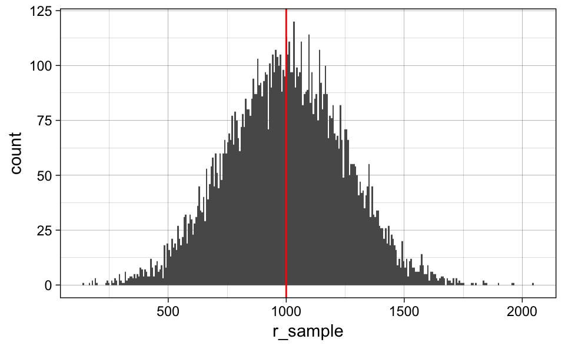

```r
data.frame(r_sample = rnorm(n = 10000, mean = 1000, sd = 250)) %>%
  ggplot(aes(x = r_sample)) +
  geom_histogram(bins = 300) +
  geom_vline(xintercept = 1000, color = 'red') +
  theme_linedraw()
```

## Random Data in R: rpois

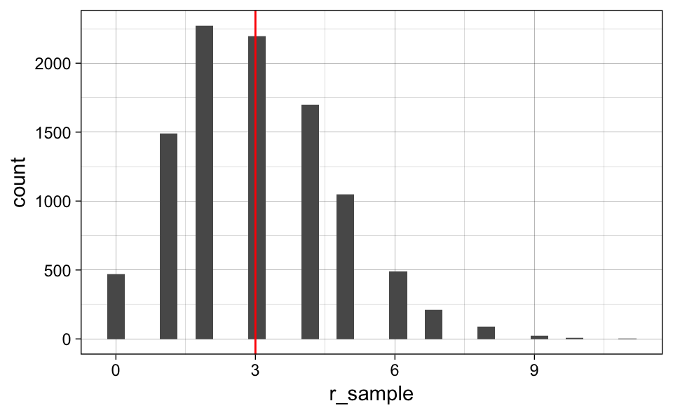

```r
data.frame(r_sample = rpois(n = 10000, lambda = 3)) %>%
  ggplot(aes(x = r_sample)) +
  geom_histogram() +
  geom_vline(xintercept = 3, color = 'red') +
  theme_linedraw()
```

## Random Data in R: rbinom

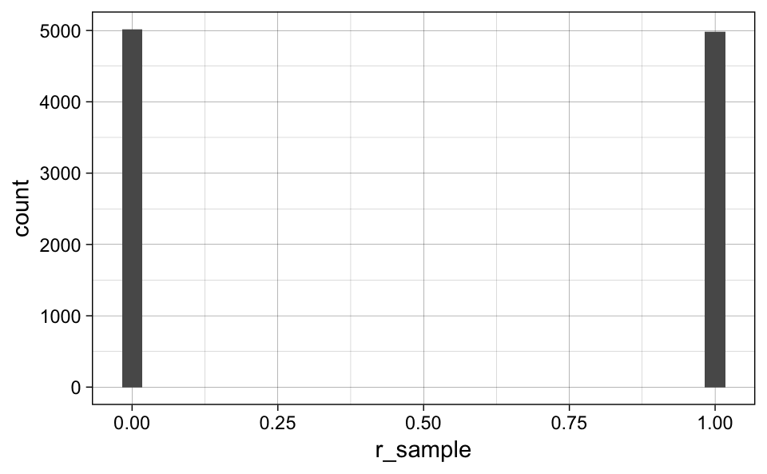

```r
data.frame(r_sample = rbinom(n = 10000, size = 1, prob = 0.5)) %>%
  ggplot(aes(x = r_sample)) +
  geom_histogram() +
  theme_linedraw()
```

## Simulations in dplyr: dplyr::slice

Def: Choose rows by their ordinal position in the tbl.

```r
slice(df, c(1, 2, 3)) # rows 1, 2 ,3
slice(df, rep(c(1, 2), each = 3)) # rows 1, 1, 1, 2, 2, 2
slice(df, rep(c(1, 2), c(2, 3))) # rows 1, 1, 2, 2, 2
```

- Simulations have nested structures with repeated obs
- For example each simu_id has 100 obs
- This saves you most of your headache while doing simulations

## Simulations in dplyr

Simulate data on 3 cars for a A/B test twice.

```r
n_simu <- 2; n_obs <- 3

data.frame(obs_id = 1:n_obs)
```

```
##   obs_id
## 1      1
## 2      2
## 3      3
```

## Simulations in dplyr

```r
n_simu <- 2; n_obs <- 3

data.frame(obs_id = 1:n_obs) %>%
  dplyr::slice(rep(obs_id, each = n_simu)) # each n_simu times
```

```
##   obs_id
## 1      1
## 2      1
## 3      2
## 4      2
## 5      3
## 6      3
```

## Simulations in dplyr

```r
n_simu <- 2; n_obs <- 3

data.frame(obs_id = 1:n_obs) %>%
  dplyr::slice(rep(obs_id, each = n_simu)) %>% # each n_simu times
  mutate(simu_id = rep(1:n_simu, n_obs)) %>% # create simu_id
  arrange(simu_id, obs_id) %>% # obs_id are nested within simu_id
  select(simu_id, obs_id)
```

```
##   simu_id obs_id
## 1       1      1
## 2       1      2
## 3       1      3
## 4       2      1
## 5       2      2
## 6       2      3
```

## Simulations in dplyr

```r
data.frame(obs_id = 1:n_obs) %>%
  dplyr::slice(rep(obs_id, each = n_simu)) %>%
  mutate(
    simu_id  = rep(1:n_simu, n_obs),
    pois_var = rpois(dplyr::n(), 10) # simulated online_views
  ) %>%
  arrange(simu_id, obs_id) %>%
  select(simu_id, obs_id, pois_var) %>%
  rename(car_id = obs_id, online_views = pois_var)
```

```
##   simu_id car_id online_views
## 1       1      1           10
## 2       1      2           10
## 3       1      3            6
## 4       2      1            8
## 5       2      2            5
## 6       2      3            7
```

## Simulating a Regression Model

To simulate a linear model you need to:

- Simulate a set of independent variables
- Define the mean as a function of the independent variables
- Simulate the outcome as a normal distribution with the defined mean

We will:

- Simulate data on online views
- Run a regression with online views as outcome
- Distribution of the effect of price on views

## Simulating a Regression Model

Simulate the number of online views.

```r
n_simu <- 2
n_obs <- 3

data.frame(car_id = seq(1, n_obs, 1)) %>%
  dplyr::slice(rep(car_id, each = n_simu)) %>%
  mutate(
    simu_id    = rep(1:n_simu, n_obs),
    price      = rpois(n(), 15), # independent variable
    miles      = rpois(n(), 25), # independent variable
    mean_views = 200 - 2*price - 2*miles, # mean(price, miles)
    num_views  = rnorm(n(), mean_views, 20) # random var with mean
  ) %>%
  arrange(simu_id, car_id) %>%
  select(simu_id, car_id, price, miles, mean_views, num_views) %>%
  head(6)
```

## Simulating a Regression Model

[output not shown]

## Simulating a Regression Model: tidyr::nest

- We want to apply a linear model to each simu_id
- We are going to group each simu_id in its own dataframe (tidyr::nest)
- Run the linear model separately on dataframe (purrr:map)
- Unnest the results (tidyr::unnest)

```r
tidyr::nest(dt, simu_id)
```

## Simulating a Regression Model: tidyr::nest

```r
data.frame(car_id = seq(1, n_obs, 1)) %>%
  dplyr::slice(rep(car_id, each = n_simu)) %>%
  mutate(
    simu_id    = rep(1:n_simu, n_obs),
    price      = rpois(n(), 15),
    miles      = rpois(n(), 25),
    mean_views = 200 - 2*price - 2*miles,
    num_views  = rnorm(n(), mean_views, 20)
  ) %>%
  arrange(simu_id, car_id) %>%
  select(simu_id, car_id, price, miles, mean_views, num_views) %>%
  group_by(simu_id) %>% # needed for nest() below
  tidyr::nest() # nest the data by each simu_id
```

## Simulating a Regression Model: tidyr::nest

```r
simu_nested <-
  data.frame(car_id = seq(1, n_obs, 1)) %>%
  dplyr::slice(rep(car_id, each = n_simu)) %>%
  mutate(
    simu_id    = rep(1:n_simu, n_obs),
    price      = rpois(n(), 15),
    miles      = rpois(n(), 25),
    mean_views = 200 - 2*price - 2*miles,
    num_views  = rnorm(n(), mean_views, 20)
  ) %>%
  group_by(simu_id) %>%
  nest()
```

## Simulating a Regression Model: tidyr::nest

```r
names(simu_nested)
```

```
## [1] "simu_id" "data"
```

```r
simu_nested$data[[1]] %>%
  head(3)
```

```
## # A tibble: 3 x 5
##   car_id price miles mean_views num_views
##    <dbl> <int> <int>      <dbl>     <dbl>
## 1      1    14    19        134      135.
## 2      2    16    24        120      115.
## 3      3    10    26        128      126.
```

## Simulating a Regression Model

Defining the linear model function:

```r
num_views_model <- function(df) {
  lm(num_views ~ price + miles, data = df)
}
```

Defining the function to get the coefficient of price:

```r
num_views_price_coef <- function(model) {
  as.numeric(model$coefficients[2])
}
```

## Simulating a Regression Model: Using purrr::map

The map functions transform their input by applying a function to each element and returning a vector the same length as the input.

```r
purrr::map(nested_df, num_views_model)
```

Run one model on each simu_id.

## Simulating a Regression Model: Using purrr::map

```r
simu_nested <-
  simu_nested %>%
  mutate(
    # Run the num_views_model on each simu_id
    model      = map(data, num_views_model),
    # After the model ran get the price coefficient
    price_coef = map(model, num_views_price_coef)
  )
```

## Simulating a Regression Model: Using purrr

```r
simu_nested$model[[1]]
```

```
##
## Call:
## lm(formula = num_views ~ price + miles, data = df)
##
## Coefficients:
## (Intercept)        price        miles
##     198.029       -1.168       -2.219
```

```r
simu_nested$price_coef[[1]]
```

```
## [1] -1.167983
```

## Simulating a Regression Model: tidyr::unnest

Nesting creates a list-column of data frames; unnesting flattens it back out into regular columns.

```r
tidyr::unnest(nested_df, summary_df)
```

## Simulating a Regression Model: tidyr::unnest

```r
simu_price_coef <-
  unnest(simu_nested, price_coef) %>% # need help with this
  select(simu_id, price_coef)

head(simu_price_coef, 3)
```

```
## # A tibble: 3 x 2
## # Groups:   simu_id [3]
##   simu_id price_coef
##     <int>      <dbl>
## 1       1      -1.17
## 2       2      -1.08
## 3       3      -1.51
```

## Simulating a Regression Model: unesting

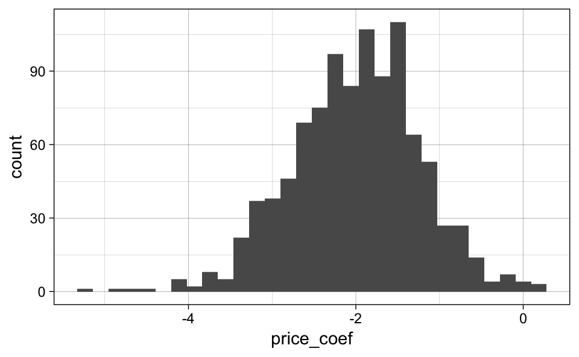

```r
simu_price_coef %>%
  ggplot(aes(x = price_coef)) +
  geom_histogram() +
  theme_linedraw()
```

## Simulating a Regression Model: Summary Statistics

```r
simu_price_coef %>%
  ungroup() %>%
  summarise(
    mean_price_coef = mean(price_coef),
    sd_price_coef   = sd(price_coef)
  )
```

```
## # A tibble: 1 x 2
##   mean_price_coef sd_price_coef
##             <dbl>         <dbl>
## 1           -2.00         0.761
```

## Power Calculation A/B Test

[figure not shown]

## Power Calculation A/B Test: Definitions

- Figure out the required sample size (n = ?)
- Interested in minimal difference (Views = 10)
- While controlling for the Type I error rate (5%)
- Obtaining a minimum power (90%)
- Plus assumptions about the data

## Power Calculations A/B Test

- You don’t need a formula!
- Simulate the data with the assumptions and inputs
- Calculate the proportion of times p-values < Type I error rate
- That is power!

## Power Calculation A/B Test: Adjusting for Covariates

- Assumptions:
  - Number of views is normally distributed
  - The number of views depends linearly on price and mileage of the car
- Inputs:
  - New layout increases the average number of views at least by 10 views
  - Sample size
- Outputs:
  - The power for the given sample size

## Power Calculation A/B Test: Adjusting for Covariates

```r
n_simu <- 2
n_obs <- 3

data.frame(car_id = seq(1, n_obs, 1)) %>%
  dplyr::slice(rep(car_id, each = n_simu)) %>%
  mutate(
    simu_id    = rep(1:n_simu, n_obs),
    price      = rpois(n(), 15),
    miles      = rpois(n(), 25),
    treatment  = rbinom(n(), 1, 0.50), # randomized treatment
    mean_views = 200 - 2* price - 2* miles + 10*treatment,
    num_views  = rnorm(n(), mean_views, 20)
  )
```

## Power Calculation A/B Test: Adjusting for Covariates

```
##   simu_id car_id price miles treatment mean_views num_views
## 1       1      1    15    24         1        132 123.60111
## 2       1      2     9    29         0        124 113.45211
## 3       1      3    17    28         0        110 136.85678
## 4       2      1    14    35         1        112  99.09604
## 5       2      2    17    20         1        136 167.00747
## 6       2      3    17    24         0        118 141.42582
```

## Power Calculation A/B Test: with and without adjustment

```r
num_views_model_without <- function(df) {
  lm(num_views ~ treatment, data = df)
}

num_views_model_with <- function(df) {
  lm(num_views ~ treatment + price + miles, data = df)
}

treatment_pvalue <- function(model) {
  summary(model)$coefficients[2, 4]
}
```

## Power Calculation A/B Test: with and without adjustment

```r
simu_ab <-
  data.frame(car_id = seq(1, n_obs, 1)) %>%
  dplyr::slice(rep(car_id, each = n_simu)) %>%
  mutate(
    simu_id    = rep(1:n_simu, n_obs),
    price      = rpois(n(), 15),
    miles      = rpois(n(), 25),
    treatment  = rbinom(n(), 1, 0.50),
    mean_views = 200 - 2*price - 2*miles + 10*treatment,
    num_views  = rnorm(n(), mean_views, 20)
  )
```

## Power Calculation A/B Test: with and without adjustment

```r
simu_ab_nested <-
  simu_ab %>%
  group_by(simu_id) %>%
  nest() %>%
  mutate(
    model_without   = map(data, num_views_model_without),
    model_with      = map(data, num_views_model_with),
    pvalues_without = map(model_without, treatment_pvalue),
    pvalues_with    = map(model_with, treatment_pvalue)
  )

names(simu_ab_nested)
```

```
## [1] "simu_id"         "data"            "model_without"   "model_with"
## [5] "pvalues_without" "pvalues_with"
```

## Power Calculation A/B Test: with and without adjustment

```r
simu_ab_nested$model_without[[1]]$coefficients
```

```
## (Intercept)   treatment
##   117.34793    14.26929
```

```r
simu_ab_nested$model_with[[1]]$coefficients
```

```
## (Intercept)   treatment       price       miles
##  181.371428   16.948224   -1.395408   -1.738635
```

## Power Calculation A/B Test: with and without adjustment

```r
simu_ab_nested$pvalues_without[[1]]
```

```
## [1] 0.003314815
```

```r
simu_ab_nested$pvalues_with[[1]]
```

```
## [1] 0.0001615344
```

## Power Calculation A/B Test: Power of the test

```r
simu_ab_pvalues_without <-
  simu_ab_nested %>%
  unnest(pvalues_without) %>%
  select(simu_id, pvalues_without)

simu_ab_pvalues_with <-
  simu_ab_nested %>%
  unnest(pvalues_with) %>%
  select(simu_id, pvalues_with)
```

## Power Calculation A/B Test: Power of the test

```r
simu_ab_pvalues_with %>%
  ungroup() %>%
  summarise(power_with = mean(pvalues_with < 0.05))
```

```
## # A tibble: 1 x 1
##   power_with
##        <dbl>
## 1      0.675
```

## Power Calculation A/B Test: Power of the test

```r
simu_ab_pvalues_without %>%
  ungroup() %>%
  summarise(power_without = mean(pvalues_without < 0.05))
```

```
## # A tibble: 1 x 1
##   power_without
##           <dbl>
## 1          0.56
```

## Simulations to Create aRt: Manfred Mohr

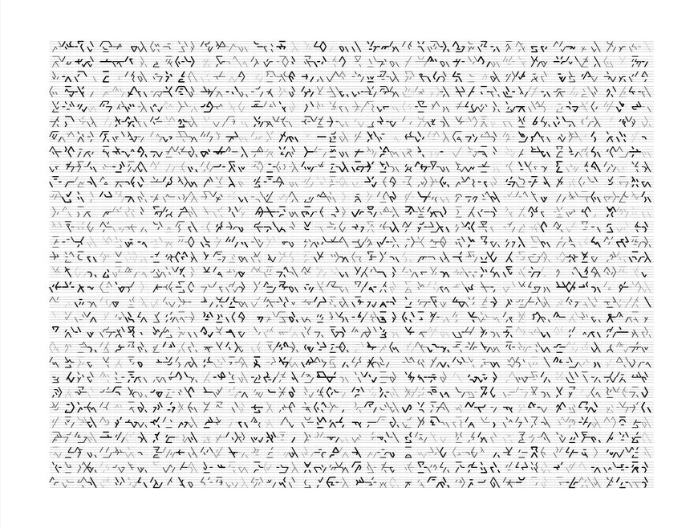

## Simulations to Create aRt

```r
n_steps_x <- 10
n_steps_y <- 5

dots_df <-
  data.frame(n_lines = rpois(1, 10) + 1) %>% # number of lines
  dplyr::slice(rep(1, n_lines)) %>%
  mutate(
    line_id      = 1:n(), # assign an id to each line
    line_x_start = sample(2:(n_steps_x - 1), n(), replace = TRUE),
    line_y_start = sample(1:n_steps_y, n(), replace = TRUE),
    line_length  = rdunif(n(), 1, 3),
    line_thick   = rdunif(n(), 1, 5)
  ) %>%
  dplyr::slice(rep(line_id, line_length)) %>%
  select(-n_lines)
```

## Simulations to Create aRt

```r
dots_df %>% head(4)
```

```
##   line_id line_x_start line_y_start line_length line_thick
## 1       1            6            2           1          1
## 2       2            9            3           2          2
## 3       2            9            3           2          2
## 4       3            8            4           2          2
```

## Simulations to Create aRt

```r
lines_df <-
  dots_df %>%
  group_by(line_id) %>%
  mutate(
    x_axis_line  = line_x_start + 0:(n() - 1),
    y_axis_steps = sample(c(-1, 1), n(), replace = TRUE),
    y_axis_line  = line_y_start + y_axis_steps
  ) %>%
  ungroup()
```

## Simulations to Create aRt

```r
lines_df %>%
  ggplot(aes(
             x = x_axis_line,
             y = y_axis_line,
             group = as.factor(line_id),
             size = line_thick
         ),
         color = 'black') +
  geom_line() +
  geom_hline(yintercept = 1, size = 0.1) +
  geom_hline(yintercept = 2, size = 0.1) +
  geom_hline(yintercept = 3, size = 0.1) +
  geom_hline(yintercept = 4, size = 0.1) +
  geom_hline(yintercept = 5, size = 0.1) +
  ylim(1, 5) +
  theme_void() +
  theme(legend.position = 'none')
```

## Simulations to Create aRt

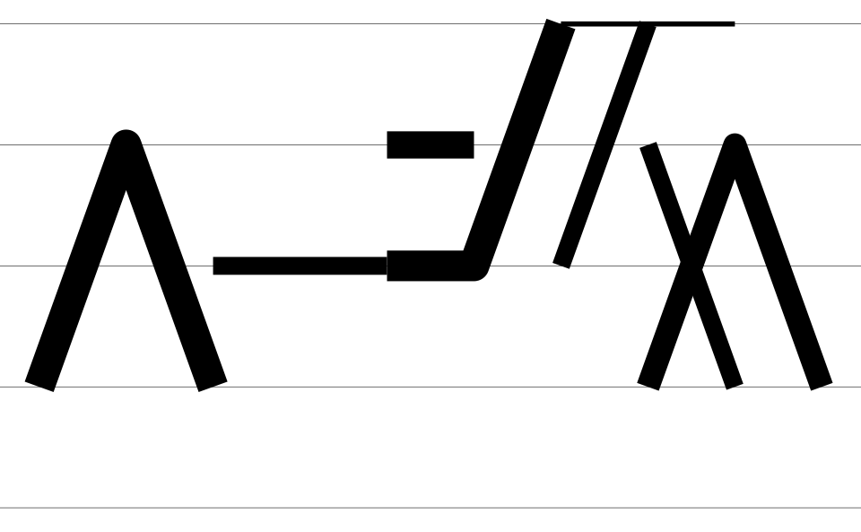

## Simulations to Create aRt

```r
n_squares <- 20^2
n_steps_x <- 10
n_steps_y <- 5

data.frame(squares_id = seq(1:n_squares)) %>%
  mutate(n_lines = rpois(1, 6) + 1) %>% # number of lines
  dplyr::slice(rep(1:n(), n_lines)) %>%
  mutate(
    line_id      = 1:n(), # assign an id to each line
    line_x_start = sample(2:(n_steps_x - 1), n(), replace = TRUE),
    line_y_start = sample(1:n_steps_y, n(), replace = TRUE),
    line_length  = rdunif(n(), 2, 4),
    line_thick   = rdunif(n(), 1, 3)
  ) %>%
  dplyr::slice(rep(line_id, line_length)) %>%
  select(-n_lines) %>%
  group_by(line_id) %>% # continues
```

## Simulations to Create aRt

[figure not shown]

## Simulations to Create aRt

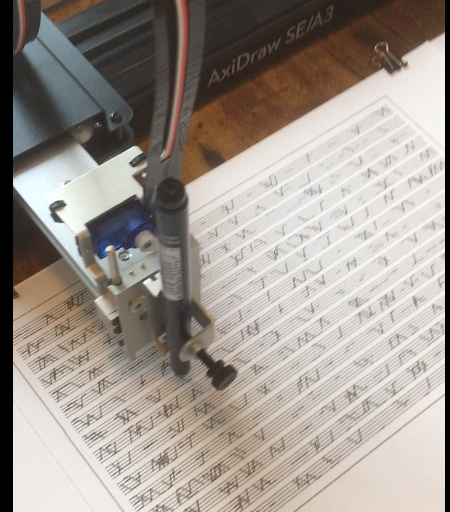

## Simulations to Create aRt

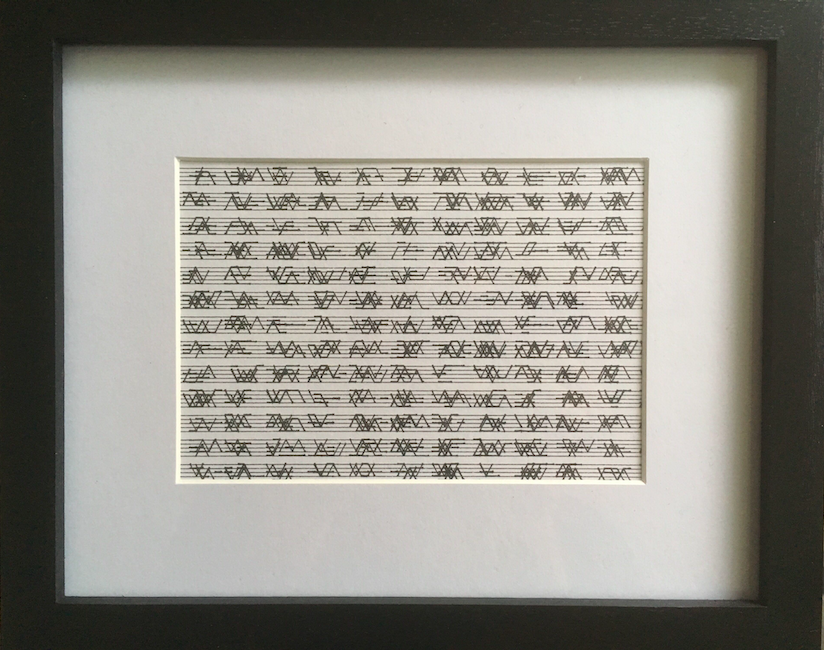

## Simulations to Create aRt

You can all be aRtists!

## Thank You

Special Thanks to:

- Ludmila Janda
- Jean-Francois Blanchette-Guertin